# 2. Correlation Analysis

Exploring relationships between variables

Author

Gustavo Roa

# Correlation Analysis

Correlation describes the **strength and direction of the association between two variables**.

In agricultural research, we may ask:

> Is grain yield associated with biomass production?

Or:

> Are two measurements of the same nutrient associated with each other?

The correlation coefficient ranges from **−1 to +1**.

- Positive values indicate that the variables tend to increase together.
- Negative values indicate that one variable tends to increase as the other decreases.
- Values near zero indicate little association.

> **Correlation describes association, not causation.**

# Types of correlation

Several correlation coefficients can be used to measure association. The most common are **Pearson’s** $(r)$, **Spearman’s** $(\rho_s)$, and **Kendall’s** $(\tau)$.

Although all three range from −1 to +1, they measure association in different ways.

# Interpreting correlation coefficients

All three correlation coefficients range from **−1 to +1**.

The **sign** indicates the direction of the association:

- **Positive:** as one variable increases, the other tends to increase.
- **Negative:** as one variable increases, the other tends to decrease.

The **absolute value** indicates the strength of the association:

- Values close to **1** indicate a strong association.
- Values close to **0** indicate a weak association.

For example:

- (r = 0.90): strong positive association.
- (r = -0.90): strong negative association.
- (r = 0.15): weak positive association.
- (r = -0.10): weak negative association.

There is no universal cutoff for what constitutes a “weak” or “strong” correlation. Interpretation should consider the scientific context and the type of correlation being used.

> **Important:** The meaning of the coefficient depends on the method. Pearson measures linear association, whereas Spearman and Kendall measure rank-based association.

## Pearson correlation

Pearson correlation measures the **strength and direction of a linear relationship** between two quantitative variables.

The population correlation coefficient is:

$$\rho =
\frac{\operatorname{Cov}(X,Y)}
{\sigma_X \sigma_Y}$$

The sample Pearson correlation is calculated as:

$$r =
\frac{
\sum_{i=1}^{n}(x_i-\bar{x})(y_i-\bar{y})
}{
\sqrt{\sum_{i=1}^{n}(x_i-\bar{x})^2}
\sqrt{\sum_{i=1}^{n}(y_i-\bar{y})^2}
}$$

where:

- $x_i$ and $y_i$ are the observations for variables (X) and (Y);
- $\bar{x}$ and $\bar{y}$ are their sample means;
- $n$ is the number of paired observations.

### When to use Pearson correlation

Pearson correlation is appropriate when:

- both variables are quantitative;
- the relationship is approximately linear;
- observations are paired;
- extreme observations are not driving the relationship.

Pearson correlation is sensitive to outliers because it uses the original values of the observations.

## Spearman correlation

Spearman $(\rho_s)$ correlation is a **rank-based** measure of association.

Instead of calculating the correlation using the original values, we first replace each observation with its rank and then calculate the correlation between the ranks.

If there are no tied ranks, Spearman’s correlation can be calculated as:

$$\rho_s =
1 -
\frac{6\sum d_i^2}
{n(n^2-1)}$$

where:

- $d_i$ is the difference between the ranks of $X_i$ and $Y_i$;
- $n$ is the number of paired observations.

The coefficient also ranges from −1 to +1.

Spearman $(\rho_s)$ correlation measures a **monotonic relationship**.

A monotonic relationship means that as one variable increases, the other generally tends to move in one direction, even if the relationship is not a straight line.

For example, a variable may increase rapidly at first and then level off. The relationship is not linear, but it can still be strongly monotonic.

### When to use Spearman correlation

Spearman correlation can be useful when:

- the relationship is monotonic but not linear;
- variables are ordinal or ranked;
- data are strongly skewed;
- outliers make a rank-based measure more appropriate.

## Kendall correlation

Kendall’s $(\tau)$ is another **rank-based** measure.

Instead of comparing the actual numerical values, Kendall correlation compares the **ordering of pairs of observations**.

For two observations, a pair is:

- **Concordant** when both variables have the same ordering.
- **Discordant** when the variables have opposite ordering.

A simplified form of Kendall’s tau is:

$$\tau =
\frac{C-D}
{\frac{1}{2}n(n-1)}$$

where:

- $C$ is the number of concordant pairs;
- $D$ is the number of discordant pairs;
- $n$ is the number of observations.

Kendall’s $(\tau)$ also ranges from −1 to +1.

### When to use Kendall correlation

Kendall correlation can be useful when:

- variables are ordinal;
- sample sizes are small;
- there are many tied observations;
- a rank-based measure of association is appropriate.

# Comparing the three methods

| Method | Based on | Measures | Main use |
| --- | --- | --- | --- |
| **Pearson** $(r)$ | Original values | Linear association | Quantitative variables with an approximately linear relationship |
| **Spearman** $\rho_s$ | Ranks | Monotonic association | Ordinal, skewed, or nonlinear monotonic relationships |
| **Kendall** $\tau$ | Concordant and discordant pairs | Rank association | Ordinal data, small samples, or many ties |

A useful way to remember the difference:

> **Pearson:** How closely do the values follow a straight line?

> **Spearman:** Do the variables generally move in the same direction when ranked?

> **Kendall:** Do the two variables have a similar ordering?

# Choosing a correlation method

The choice should be based on the **research question and the structure of the data**, not simply on whether a normality test is significant.

A useful workflow is:

1. Identify the type of variables.
2. Plot the relationship.
3. Determine whether the relationship is linear or monotonic.
4. Check for unusual observations.
5. Select the correlation method that matches the research question.

For this workshop, we will use **Pearson correlation** for the hands-on example because our variables are quantitative and we want to examine their linear association.

# Load the required packages

We will use:

- `readxl` to import the Excel dataset.
- `dplyr` to select variables.
- `ggplot2` to create graphs.
- `corrplot` to visualize the correlation matrix.

```r
# Import Excel files
library(readxl)

# Select and manipulate variables
library(dplyr)

# Create graphs
library(ggplot2)

# Visualize correlation matrices
library(corrplot)
```

# Load the data

We will use the same agronomic dataset from the previous section.

```r
# Import the workshop dataset
AllData <- read_excel(
  "Data_example.xlsx",
  sheet = "data"
)

# Check the structure and variable types
str(AllData)
```

```
tibble [20 × 11] (S3: tbl_df/tbl/data.frame)
 $ year             : num [1:20] 2022 2022 2022 2022 2022 ...
 $ location         : chr [1:20] "Ashland" "Ashland" "Ashland" "Ashland" ...
 $ block            : num [1:20] 1 1 1 1 1 2 2 2 2 2 ...
 $ S_rate_kg_ha     : num [1:20] 34 11 45 22 0 0 34 22 11 45 ...
 $ grain_yield_Mg_ha: num [1:20] 9.04 10.66 11.25 10.06 7.75 ...
 $ biomass_V6_Mg_ha : num [1:20] 0.39 0.46 0.48 0.38 0.69 0.35 0.49 0.75 0.68 0.59 ...
 $ biomass_R1_Mg_ha : num [1:20] 7.82 8.52 7.6 7.47 10.3 ...
 $ S_conc_V6_pct    : num [1:20] 0.28 0.24 0.29 0.25 0.23 0.25 0.25 0.24 0.24 0.25 ...
 $ N_conc_V6_pct    : num [1:20] 3.86 3.65 3.78 3.67 3.74 3.93 3.8 3.68 3.87 3.66 ...
 $ S_conc_R1_pct    : num [1:20] 0.15 0.13 0.14 0.12 0.13 0.16 0.13 0.13 0.11 0.14 ...
 $ N_conc_R1_pct    : num [1:20] 1.7 1.57 1.7 1.38 1.59 1.81 1.62 1.6 1.41 1.63 ...
```

# Pearson correlation

Let’s examine the relationship between **R1 biomass and grain yield**.

Our question is:

> **Is greater R1 biomass associated with greater grain yield?**

## Calculate the correlation

The `cor()` function calculates a correlation coefficient.

```r
# Calculate the Pearson correlation between R1 biomass and grain yield
cor(
  AllData$biomass_R1_Mg_ha,
  AllData$grain_yield_Mg_ha,
  method = "pearson"
)
```

```
[1] 0.3207609
```

The result describes the **direction and strength of the linear association**.

# Visualize the relationship

Before interpreting the correlation coefficient, look at the data.

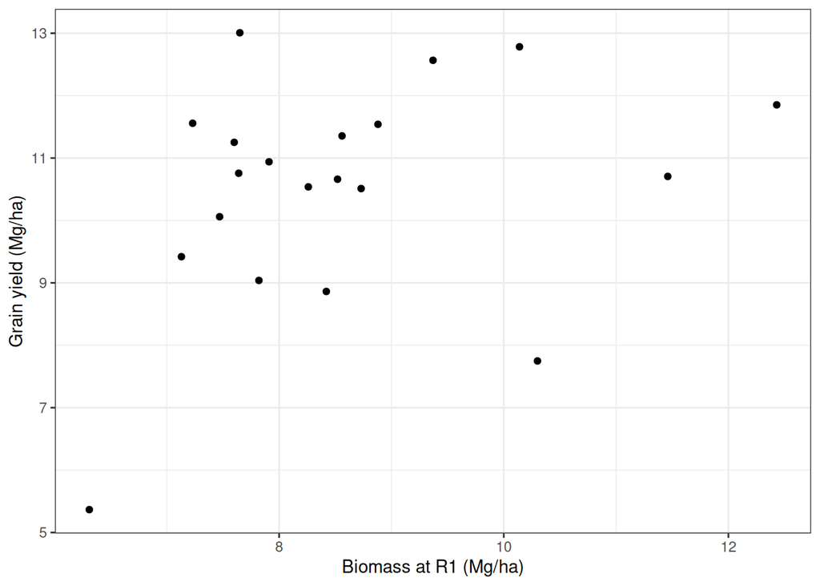

When looking at the scatterplot, ask:

- Is the relationship positive or negative?
- Does the relationship appear linear?
- How strong does the relationship appear?
- Are there unusual observations?

> **Look at the scatterplot before interpreting the correlation coefficient.**

# Correlation matrix

When several quantitative variables are available, we can calculate correlations for all pairs.

For this example, we will use the agronomic variables from sulfur rate through the R1 tissue measurements.

```r
# Select variables for the correlation analysis
cor_data <- AllData %>%
  select(S_rate_kg_ha:N_conc_R1_pct)

# Calculate the Pearson correlation matrix
M <- cor(
  cor_data,
  method = "pearson",
  use = "pairwise.complete.obs"
)

# Display the correlation matrix
round(M, 2)
```

```
                  S_rate_kg_ha grain_yield_Mg_ha biomass_V6_Mg_ha
S_rate_kg_ha              1.00              0.61             0.05
grain_yield_Mg_ha         0.61              1.00             0.30
biomass_V6_Mg_ha          0.05              0.30             1.00
biomass_R1_Mg_ha         -0.05              0.32             0.61
S_conc_V6_pct             0.24              0.00             0.04
N_conc_V6_pct            -0.14             -0.05            -0.19
S_conc_R1_pct             0.03             -0.37            -0.50
N_conc_R1_pct            -0.01             -0.35            -0.34
                  biomass_R1_Mg_ha S_conc_V6_pct N_conc_V6_pct S_conc_R1_pct
S_rate_kg_ha                 -0.05          0.24         -0.14          0.03
grain_yield_Mg_ha             0.32          0.00         -0.05         -0.37
biomass_V6_Mg_ha              0.61          0.04         -0.19         -0.50
biomass_R1_Mg_ha              1.00         -0.08          0.01         -0.26
S_conc_V6_pct                -0.08          1.00          0.23          0.12
N_conc_V6_pct                 0.01          0.23          1.00          0.18
S_conc_R1_pct                -0.26          0.12          0.18          1.00
N_conc_R1_pct                -0.25          0.23          0.12          0.88
                  N_conc_R1_pct
S_rate_kg_ha              -0.01
grain_yield_Mg_ha         -0.35
biomass_V6_Mg_ha          -0.34
biomass_R1_Mg_ha          -0.25
S_conc_V6_pct              0.23
N_conc_V6_pct              0.12
S_conc_R1_pct              0.88
N_conc_R1_pct              1.00
```

## Visualize the correlation matrix

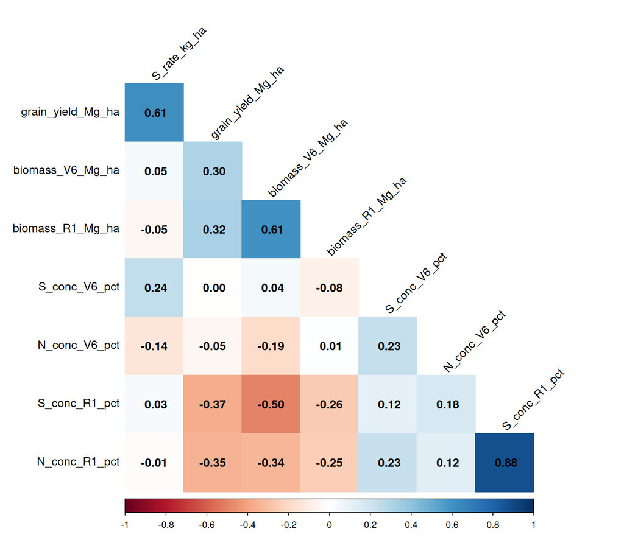

```r
# Visualize the Pearson correlation matrix
corrplot(
  M,
  method = "color",
  type = "lower",
  order = "original",
  tl.col = "black",
  tl.srt = 45,
  addCoef.col = "black",
  diag = FALSE
)
```

Values close to:

- **+1** indicate a strong positive association.
- **−1** indicate a strong negative association.
- **0** indicate a weak association.

# Exercise

## Exercise 2.1: Calculate a correlation

Calculate the Pearson correlation between:

- `N_conc_R1_pct`
- `S_conc_R1_pct`

```r
# Calculate the Pearson correlation
cor(
  AllData$____________,
  AllData$____________,
  method = "pearson"
)
```

**TipShow solution**

```r
# Calculate the Pearson correlation
cor(
  AllData$N_conc_R1_pct,
  AllData$S_conc_R1_pct,
  method = "pearson"
)
```

```
[1] 0.8784732
```

## Exercise 2.2: Create a scatterplot

Create a scatterplot for the same two variables.

```r
# Create a scatterplot
ggplot(
  AllData,
  aes(
    x = ____________,
    y = ____________
  )
) +
  geom_point() +
  labs(
    x = "____________",
    y = "____________"
  ) +
  theme_bw()
```

**TipShow solution**

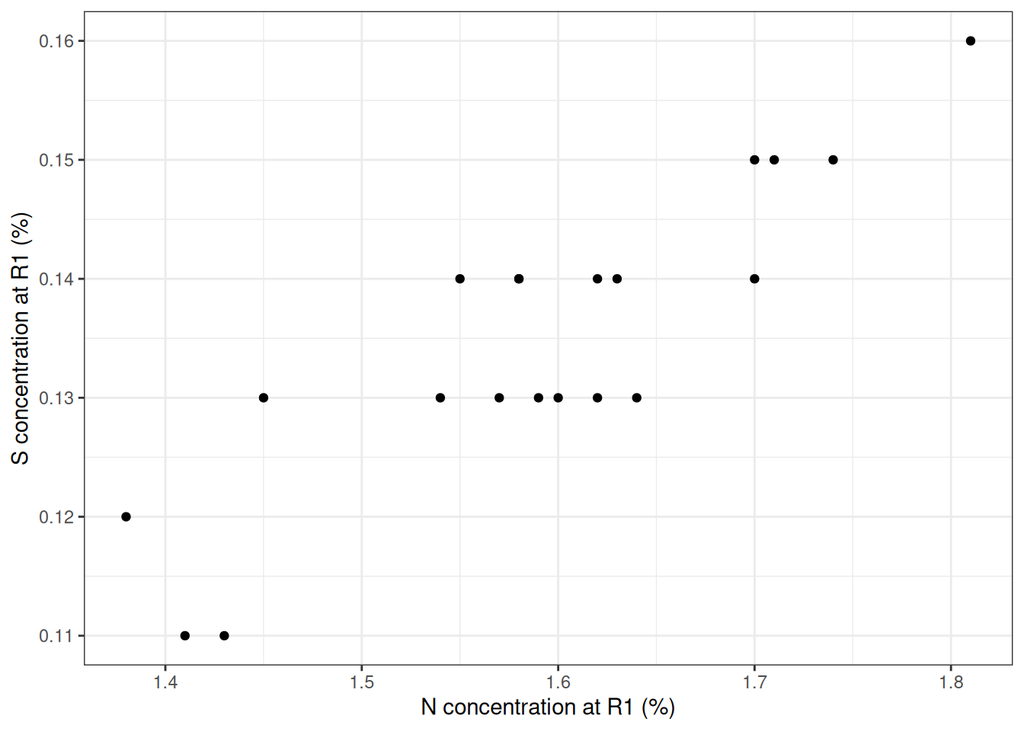

```r
# Plot R1 nitrogen and sulfur concentration
ggplot(
  AllData,
  aes(
    x = N_conc_R1_pct,
    y = S_conc_R1_pct
  )
) +
  geom_point() +
  labs(
    x = "N concentration at R1 (%)",
    y = "S concentration at R1 (%)"
  ) +
  theme_bw()
```

## Exercise 2.3: Interpret the relationship

Use your correlation coefficient and scatterplot to answer:

1. Is the relationship positive or negative?
2. How strong is the association?
3. Does the scatterplot suggest a linear relationship?
4. Are there any potentially unusual observations?

# Key takeaways

- Correlation measures the **strength and direction of association**.
- Pearson measures **linear association**.
- Spearman and Kendall are **rank-based methods**.
- The choice of method should depend on the data and research question.
- Always examine a scatterplot before interpreting a correlation.
- Correlation does not demonstrate causation.

> **Look at the data first, choose the appropriate correlation method, and then interpret the result in context.**

# Next section

Correlation describes the association between variables. In the next section, we will use **linear regression** to model how a response variable changes as a function of an explanatory variable.